# Assignment 2

Data Exploration

1. Download the dataset and store in a dataframe.

```r
bank <- read.csv("bank-full.csv", sep = ";", stringsAsFactors = FALSE, na.strings = "unknown")
```

2. Explore overall structure of the dataset using str(). Get a summary of statistics and then explain what each type of variable.

```r
str(bank)
```

```
'data.frame':   45211 obs. of  17 variables:
 $ age      : int  58 44 33 47 33 35 28 42 58 43 ...
 $ job      : chr  "management" "technician" "entrepreneur" "blue-collar" ...
 $ marital  : chr  "married" "single" "married" "married" ...
 $ education: chr  "tertiary" "secondary" "secondary" NA ...
 $ default  : chr  "no" "no" "no" "no" ...
 $ balance  : int  2143 29 2 1506 1 231 447 2 121 593 ...
 $ housing  : chr  "yes" "yes" "yes" "yes" ...
 $ loan     : chr  "no" "no" "yes" "no" ...
 $ contact  : chr  NA NA NA NA ...
 $ day      : int  5 5 5 5 5 5 5 5 5 5 ...
 $ month    : chr  "may" "may" "may" "may" ...
 $ duration : int  261 151 76 92 198 139 217 380 50 55 ...
 $ campaign : int  1 1 1 1 1 1 1 1 1 1 ...
 $ pdays    : int  -1 -1 -1 -1 -1 -1 -1 -1 -1 -1 ...
 $ previous : int  0 0 0 0 0 0 0 0 0 0 ...
 $ poutcome : chr  NA NA NA NA ...
 $ y        : chr  "no" "no" "no" "no" ...
```

```r
summary(bank)
```

```
      age            job              marital           education           default             balance
 Min.   :18.00   Length:45211       Length:45211       Length:45211       Length:45211       Min.   : -8019
 1st Qu.:33.00   Class :character   Class :character   Class :character   Class :character   1st Qu.:    72
 Median :39.00   Mode  :character   Mode  :character   Mode  :character   Mode  :character   Median :   448
 Mean   :40.94                                                                               Mean   :  1362
 3rd Qu.:48.00                                                                               3rd Qu.:  1428
 Max.   :95.00                                                                               Max.   :102127
   housing              loan             contact               day           month              duration
 Length:45211       Length:45211       Length:45211       Min.   : 1.00   Length:45211       Min.   :   0.0
 Class :character   Class :character   Class :character   1st Qu.: 8.00   Class :character   1st Qu.: 103.0
 Mode  :character   Mode  :character   Mode  :character   Median :16.00   Mode  :character   Median : 180.0
                                                          Mean   :15.81                      Mean   : 258.2
                                                          3rd Qu.:21.00                      3rd Qu.: 319.0
                                                          Max.   :31.00                      Max.   :4918.0
    campaign          pdays          previous          poutcome              y
 Min.   : 1.000   Min.   : -1.0   Min.   :  0.0000   Length:45211       Length:45211
 1st Qu.: 1.000   1st Qu.: -1.0   1st Qu.:  0.0000   Class :character   Class :character
 Median : 2.000   Median : -1.0   Median :  0.0000   Mode  :character   Mode  :character
 Mean   : 2.764   Mean   : 40.2   Mean   :  0.5803
 3rd Qu.: 3.000   3rd Qu.: -1.0   3rd Qu.:  0.0000
 Max.   :63.000   Max.   :871.0   Max.   :275.0000
```

age: Continuous

job: Categorical (unordered)

marital: Categorical (unordered)

education: Categorical (ordered)

default: Categorical (unordered)

balance: Continuous

housing: Categorical (unordered)

loan: Categorical (unordered)

contact: Categorical (unordered)

day: Continuous

month: Categorical (ordered)

duration: Continuous

campaign: Continuous

pdays: Continuous

previous: Continuous

poutcome: Categorical (unordered)

y: Categorical (unordered)

3. Get frequency table of the target variable “y”. Is y balanced?

```r
bank_y <- factor(bank$y)
table(bank_y)
```

```
bank_y
   no   yes
39922  5289
```

From the frequency table, it seems that y is not balanced.

4. Explore the data in order to investigate the association between the target variable y and other variables in the dataset.

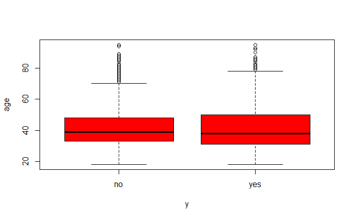

```r
attach(bank)
boxplot(age~y, col ="red")
```

```r
oneway.test(age~y, data =bank)
```

```
    One-way analysis of means (not assuming equal variances)

data:  age and y
F = 18.648, num df = 1.0, denom df = 6109.2, p-value = 1.597e-05
```

There appears to be an association with age and y.

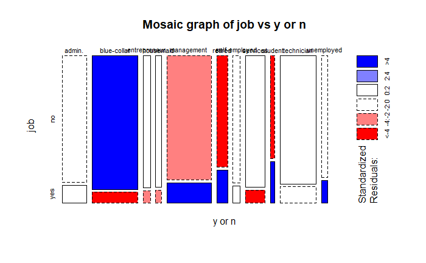

```r
job_table <- table(bank$job,bank$y)
mosaicplot(job_table, ylab = "job", xlab ="y or n", main ="Mosaic graph of job vs y or n", shade=TRUE)
```

```r
chisq.test(job_table)
```

```
    Pearson's Chi-squared test

data:  job_table
X-squared = 836.14, df = 10, p-value < 2.2e-16
```

There appears to be an association between job and y.

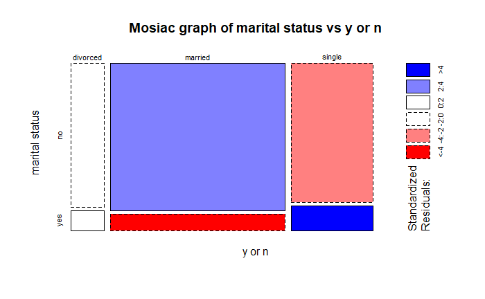

```r
marital_table <- table(bank$marital, bank$y)
mosaicplot(marital_table, ylab ="marital status", xlab ="y or n", main ="Mosiac graph of marital status vs y or n", shade=TRUE)
```

```r
chisq.test(marital_table)
```

```
    Pearson's Chi-squared test

data:  marital_table
X-squared = 196.5, df = 2, p-value < 2.2e-16
```

There appears to be an association with y and marital.

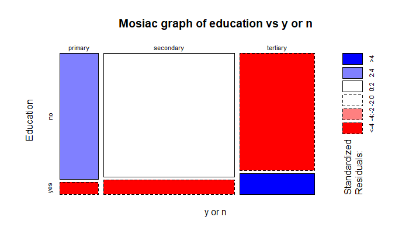

```r
edu_table <- table(bank$education, bank$y)
mosaicplot(edu_table, ylab ="Education", xlab ="y or n", main ="Mosiac graph of education vs y or n", shade=TRUE)
```

```r
chisq.test(edu_table)
```

```
    Pearson's Chi-squared test

data:  edu_table
X-squared = 233.75, df = 2, p-value < 2.2e-16
```

There appears to be an association between education and y.

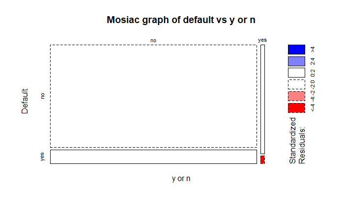

```r
default_table <- table(bank$default, bank$y)
mosaicplot(default_table, ylab ="Default", xlab ="y or n", main ="Mosiac graph of default vs y or n", shade=TRUE)
```

```r
chisq.test(default_table)
```

```
    Pearson's Chi-squared test with Yates' continuity correction

data:  default_table
X-squared = 22.202, df = 1, p-value = 2.454e-06
```

There appears to be an association with default and y

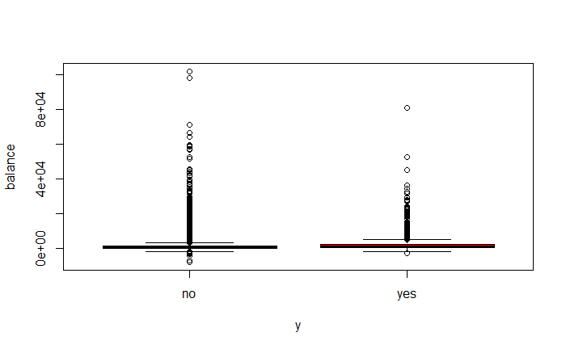

```r
boxplot(balance~y, col ="red")
```

```r
oneway.test(balance~y, data = bank)
```

```
    One-way analysis of means (not assuming equal variances)

data:  balance and y
F = 98.675, num df = 1.0, denom df = 6339.8, p-value < 2.2e-16
```

There appears to be an association with balance and y.

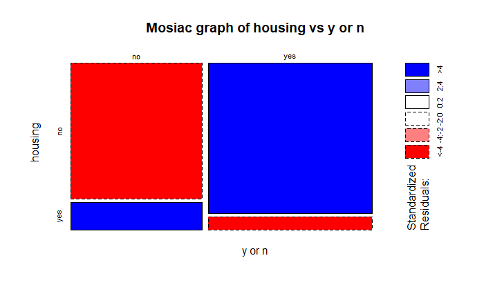

```r
housing_table <- table(bank$housing, bank$y)
mosaicplot(housing_table, ylab ="housing", xlab ="y or n", main ="Mosiac graph of housing vs y or n", shade=TRUE)
```

```r
chisq.test(housing_table)
```

```
    Pearson's Chi-squared test with Yates' continuity correction

data:  housing_table
X-squared = 874.82, df = 1, p-value < 2.2e-16
```

There appears to be an association with housing and y.

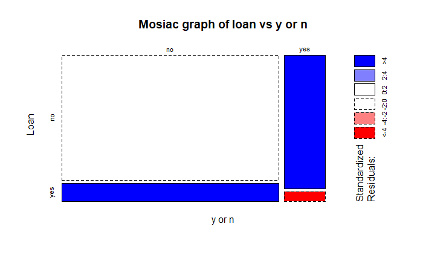

```r
loan_table <- table(bank$loan, bank$y)
mosaicplot(loan_table, ylab ="Loan", xlab ="y or n", main ="Mosiac graph of loan vs y or n", shade=TRUE)
```

```r
chisq.test(loan_table)
```

```
    Pearson's Chi-squared test with Yates' continuity correction

data:  loan_table
X-squared = 209.62, df = 1, p-value < 2.2e-16
```

There appears to be an association with loan and y.

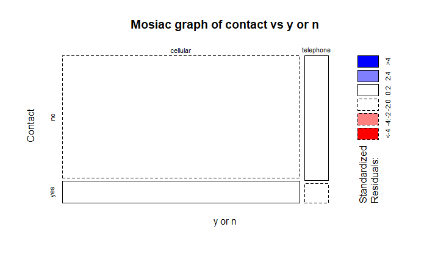

```r
contact_table <- table(bank$contact, bank$y)
mosaicplot(contact_table, ylab ="Contact", xlab ="y or n", main ="Mosiac graph of contact vs y or n", shade=TRUE)
```

```r
chisq.test(contact_table)
```

```
    Pearson's Chi-squared test with Yates' continuity correction

data:  contact_table
X-squared = 4.5932, df = 1, p-value = 0.0321
```

There appears to be an association with contact and y.

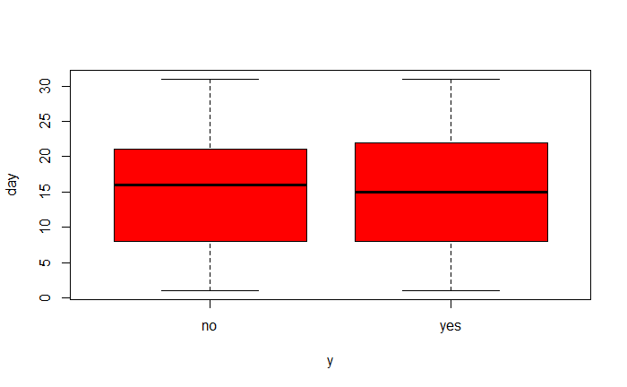

```r
boxplot(day~y, col="red")
```

```r
oneway.test(day~y, data =bank)
```

```
    One-way analysis of means (not assuming equal variances)

data:  day and y
F = 35.011, num df = 1.0, denom df = 6691.7, p-value = 3.441e-09
```

There appears to be an association with day and y.

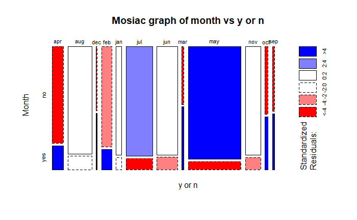

```r
month_table <- table(bank$month, bank$y)
mosaicplot(month_table, ylab ="Month", xlab ="y or n", main ="Mosiac graph of month vs y or n", shade=TRUE)
```

```r
chisq.test(month_table)
```

```
    Pearson's Chi-squared test

data:  month_table
X-squared = 3061.8, df = 11, p-value < 2.2e-16
```

There appears to be an association with month and y.

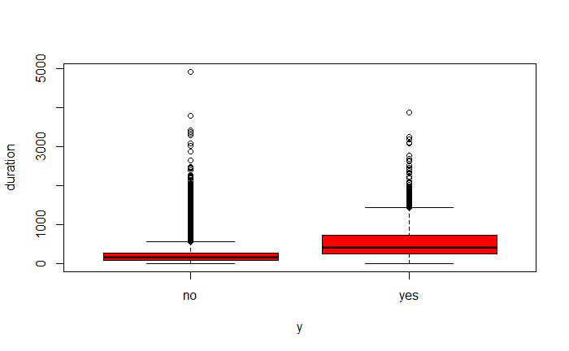

```r
boxplot(duration~y, col="red")
```

```r
oneway.test(duration~y, data = bank)
```

```
    One-way analysis of means (not assuming equal variances)

data:  duration and y
F = 3307.9, num df = 1.0, denom df = 5685.3, p-value < 2.2e-16
```

There appears to be an association with duration and y.

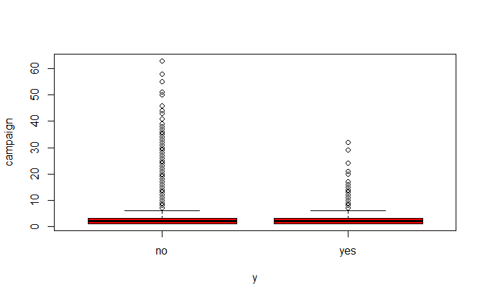

```r
boxplot(campaign~y, col="red")
```

```r
oneway.test(campaign~y)
```

```
    One-way analysis of means (not assuming equal variances)

data:  campaign and y
F = 519.87, num df = 1.0, denom df = 9751.6, p-value < 2.2e-16
```

There appears to be an association with campaign and y.

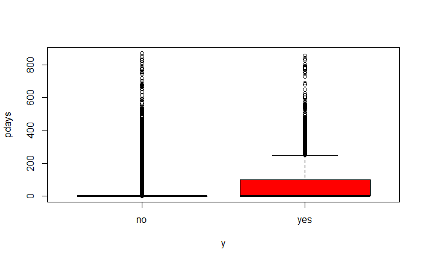

```r
boxplot(pdays~y, col="red")
```

```r
oneway.test(pdays~y, data = bank)
```

```
    One-way analysis of means (not assuming equal variances)

data:  pdays and y
F = 358.86, num df = 1.0, denom df = 6251.5, p-value < 2.2e-16
```

There appears to be an association with pdays and y.

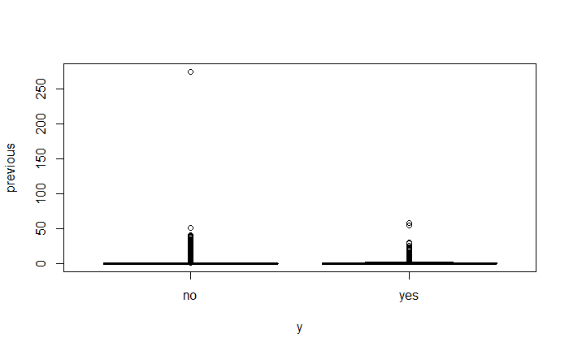

```r
boxplot(previous~y, col="red")
```

```r
oneway.test(previous~y, data =bank)
```

```
    One-way analysis of means (not assuming equal variances)

data:  previous and y
F = 328.26, num df = 1.0, denom df = 6430.1, p-value < 2.2e-16
```

There appears to be an asssociation with previous and y.

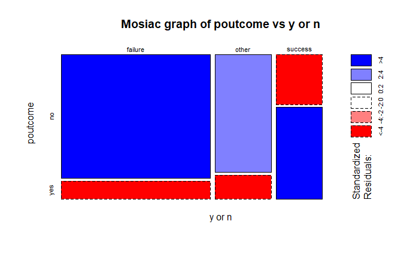

```r
pout_table <- table(bank$poutcome,bank$y)
mosaicplot(pout_table, ylab ="poutcome", xlab ="y or n", main ="Mosiac graph of poutcome vs y or n", shade=TRUE)
```

```r
chisq.test(pout_table)
```

```
    Pearson's Chi-squared test

data:  pout_table
X-squared = 1822.2, df = 2, p-value < 2.2e-16
```

There appears to be an association with poutcome and y.

```r
colSums(is.na(bank))
```

```
      age       job   marital education   default   balance   housing      loan   contact       day     month
        0       288         0      1857         0         0         0         0     13020         0         0
 duration  campaign     pdays  previous  poutcome         y
        0         0         0         0     36959         0
```

Job, education, contact, and poutcome have missing values.

```r
calc_mode <- function(x){
  unique_val <- na.omit(unique(x))
  unique_tab <- tabulate(match(x, unique_val))
  unique_val[which.max(unique_tab)]
}

bank$job[is.na(bank$job)] <- calc_mode(bank$job)
bank$education[is.na(bank$education)] <- calc_mode(bank$education)
bank$contact[is.na(bank$contact)] <- calc_mode(bank$contact)
bank$poutcome[is.na(bank$poutcome)] <- calc_mode(bank$poutcome)
colSums(is.na(bank))
```

```
      age       job   marital education   default   balance   housing      loan   contact       day     month
        0         0         0         0         0         0         0         0         0         0         0
 duration  campaign     pdays  previous  poutcome         y
        0         0         0         0         0         0
```

7. Set seed of random number generator to fixed integer
8. Randomize the order of the rows

```r
set.seed(1)
shuffle_bank <- bank[sample(nrow(bank), replace =FALSE),]
str(shuffle_bank)
```

```
'data.frame':   45211 obs. of  17 variables:
 $ age      : int  31 38 27 57 38 55 53 30 40 45 ...
 $ job      : chr  "admin." "management" "admin." "retired" ...
 $ marital  : chr  "married" "married" "single" "married" ...
 $ education: chr  "tertiary" "secondary" "secondary" "secondary" ...
 $ default  : chr  "no" "no" "no" "no" ...
 $ balance  : int  1144 76 276 2020 3139 1187 61 603 7313 1678 ...
 $ housing  : chr  "yes" "no" "yes" "no" ...
 $ loan     : chr  "yes" "no" "no" "no" ...
 $ contact  : chr  "cellular" "cellular" "cellular" "cellular" ...
 $ day      : int  17 16 19 19 18 17 10 2 18 18 ...
 $ month    : chr  "nov" "mar" "may" "jun" ...
 $ duration : int  89 261 311 93 177 113 190 335 241 187 ...
 $ campaign : int  1 1 2 4 2 1 1 2 2 1 ...
 $ pdays    : int  -1 -1 -1 -1 -1 319 -1 -1 182 154 ...
 $ previous : int  0 0 0 0 0 2 0 0 1 1 ...
 $ poutcome : chr  "failure" "failure" "failure" "failure" ...
 $ y        : chr  "no" "yes" "no" "no" ...
```

```r
shuffle_bank$month <- c(jan = 1, feb = 2,mar = 3, apr = 4, may = 5, jun = 6, jul = 7, aug = 8, sep = 9, oct = 10, nov = 11, dec = 12)[shuffle_bank$month]
shuffle_bank$education <- c(primary = 1, secondary = 2, tertiary = 3)[shuffle_bank$education]
```

9. One-hot encoding

```r
library(data.table)
bank_dt <- as.data.table(shuffle_bank)
class(bank_dt)
```

```
[1] "data.table" "data.frame"
```

```r
bank_dt$job <- factor(bank_dt$job)
bank_dt$marital <- factor(bank_dt$marital)
bank_dt$default <- factor(bank_dt$default)
bank_dt$housing <- factor(bank_dt$housing)
bank_dt$loan <- factor(bank_dt$loan)
bank_dt$contact <- factor(bank_dt$contact)
bank_dt$poutcome <- factor(bank_dt$poutcome)
bank_one_hot <-one_hot(bank_dt, cols = c("job","marital","default","housing","loan","contact","poutcome"), sparsifyNAs = FALSE, naCols =FALSE, dropCols =TRUE, dropUnusedLevels = TRUE)
```

[output not shown]

```r
#convert data table back to data frame
bank_frame <- as.data.frame(bank_one_hot, row.names =NULL, optional = FALSE)
class(bank_frame)
```

```
[1] "data.frame"
```

```r
#bank_frame_n <-bank_frame[1:34]
```

10. Split data to training and test sets with the first 36168 rows for training and the rest for testing.

```r
bank_train <- bank_frame[1:36168, ]
bank_test <- bank_frame[36169:45211, ]
bank_train_labels <- bank_frame[1:36168, 35]
bank_test_labels <- bank_frame[36169:45211, 35]

#one_hot_frame = subset(bank_one_hot, select= -c(age,balance,day,duration,campaign,pdays,previous))
bank_train
```

|  | age | job_admin. | job_blue-collar | job_entrepreneur | job_housemaid | job_management | job_retired | job_self-employed | job_services | job_student | job_technician | job_unemployed | marital_divorced | marital_married | marital_single | education | default_no | default_yes | balance | housing_no | housing_yes | loan_no | loan_yes | contact_cellular | contact_telephone | day | month | duration | campaign | … |
| --- | --- | --- | --- | --- | --- | --- | --- | --- | --- | --- | --- | --- | --- | --- | --- | --- | --- | --- | --- | --- | --- | --- | --- | --- | --- | --- | --- | --- | --- | --- |
| 1 | 31 | 1 | 0 | 0 | 0 | 0 | 0 | 0 | 0 | 0 | 0 | 0 | 0 | 1 | 0 | 3 | 1 | 0 | 1144 | 0 | 1 | 0 | 1 | 1 | 0 | 17 | 11 | 89 | 1 | … |
| 2 | 38 | 0 | 0 | 0 | 0 | 1 | 0 | 0 | 0 | 0 | 0 | 0 | 0 | 1 | 0 | 2 | 1 | 0 | 76 | 1 | 0 | 1 | 0 | 1 | 0 | 16 | 3 | 261 | 1 | … |
| 3 | 27 | 1 | 0 | 0 | 0 | 0 | 0 | 0 | 0 | 0 | 0 | 0 | 0 | 0 | 1 | 2 | 1 | 0 | 276 | 0 | 1 | 1 | 0 | 1 | 0 | 19 | 5 | 311 | 2 | … |
| 4 | 57 | 0 | 0 | 0 | 0 | 0 | 1 | 0 | 0 | 0 | 0 | 0 | 0 | 1 | 0 | 2 | 1 | 0 | 2020 | 1 | 0 | 1 | 0 | 1 | 0 | 19 | 6 | 93 | 4 | … |
| 5 | 38 | 0 | 0 | 0 | 0 | 0 | 0 | 1 | 0 | 0 | 0 | 0 | 0 | 1 | 0 | 3 | 1 | 0 | 3139 | 0 | 1 | 1 | 0 | 1 | 0 | 18 | 11 | 177 | 2 | … |
| 6 | 55 | 0 | 1 | 0 | 0 | 0 | 0 | 0 | 0 | 0 | 0 | 0 | 0 | 0 | 1 | 1 | 1 | 0 | 1187 | 0 | 1 | 1 | 0 | 1 | 0 | 17 | 4 | 113 | 1 | … |
| 7 | 53 | 0 | 0 | 0 | 0 | 0 | 1 | 0 | 0 | 0 | 0 | 0 | 0 | 1 | 0 | 1 | 1 | 0 | 61 | 1 | 0 | 0 | 1 | 1 | 0 | 10 | 7 | 190 | 1 | … |
| 8 | 30 | 0 | 0 | 0 | 0 | 0 | 0 | 0 | 1 | 0 | 0 | 0 | 0 | 0 | 1 | 2 | 1 | 0 | 603 | 0 | 1 | 0 | 1 | 1 | 0 | 2 | 6 | 335 | 2 | … |
| 9 | 40 | 0 | 0 | 0 | 0 | 0 | 0 | 0 | 0 | 0 | 1 | 0 | 0 | 1 | 0 | 2 | 1 | 0 | 7313 | 0 | 1 | 1 | 0 | 1 | 0 | 18 | 11 | 241 | 2 | … |
| 10 | 45 | 0 | 1 | 0 | 0 | 0 | 0 | 0 | 0 | 0 | 0 | 0 | 0 | 1 | 0 | 2 | 1 | 0 | 1678 | 0 | 1 | 1 | 0 | 1 | 0 | 18 | 11 | 187 | 1 | … |

[output cut: 990 more lines]

```r
bank_test
```

|  | age | job_admin. | job_blue-collar | job_entrepreneur | job_housemaid | job_management | job_retired | job_self-employed | job_services | job_student | job_technician | job_unemployed | marital_divorced | marital_married | marital_single | education | default_no | default_yes | balance | housing_no | housing_yes | loan_no | loan_yes | contact_cellular | contact_telephone | day | month | duration | campaign | … |
| --- | --- | --- | --- | --- | --- | --- | --- | --- | --- | --- | --- | --- | --- | --- | --- | --- | --- | --- | --- | --- | --- | --- | --- | --- | --- | --- | --- | --- | --- | --- |
| 36169 | 32 | 1 | 0 | 0 | 0 | 0 | 0 | 0 | 0 | 0 | 0 | 0 | 0 | 0 | 1 | 2 | 1 | 0 | 1465 | 1 | 0 | 1 | 0 | 0 | 1 | 30 | 1 | 118 | 5 | … |
| 36170 | 33 | 0 | 0 | 0 | 0 | 1 | 0 | 0 | 0 | 0 | 0 | 0 | 0 | 0 | 1 | 3 | 1 | 0 | 201 | 0 | 1 | 1 | 0 | 1 | 0 | 19 | 11 | 171 | 1 | … |
| 36171 | 55 | 0 | 0 | 0 | 0 | 0 | 0 | 0 | 0 | 0 | 1 | 0 | 0 | 1 | 0 | 2 | 1 | 0 | 1938 | 1 | 0 | 0 | 1 | 1 | 0 | 18 | 8 | 193 | 1 | … |
| 36172 | 31 | 0 | 0 | 0 | 0 | 0 | 0 | 0 | 0 | 0 | 1 | 0 | 0 | 0 | 1 | 3 | 1 | 0 | 56 | 1 | 0 | 1 | 0 | 1 | 0 | 15 | 5 | 320 | 3 | … |
| 36173 | 35 | 0 | 0 | 0 | 0 | 1 | 0 | 0 | 0 | 0 | 0 | 0 | 0 | 1 | 0 | 3 | 1 | 0 | 46 | 0 | 1 | 1 | 0 | 1 | 0 | 13 | 8 | 96 | 2 | … |
| 36174 | 50 | 0 | 0 | 0 | 0 | 1 | 0 | 0 | 0 | 0 | 0 | 0 | 0 | 1 | 0 | 2 | 1 | 0 | 3002 | 1 | 0 | 1 | 0 | 1 | 0 | 8 | 8 | 125 | 2 | … |
| 36175 | 54 | 0 | 1 | 0 | 0 | 0 | 0 | 0 | 0 | 0 | 0 | 0 | 0 | 1 | 0 | 2 | 1 | 0 | 1636 | 1 | 0 | 1 | 0 | 0 | 1 | 20 | 7 | 1008 | 2 | … |
| 36176 | 40 | 0 | 0 | 0 | 0 | 0 | 0 | 0 | 0 | 0 | 0 | 1 | 0 | 0 | 1 | 2 | 1 | 0 | 356 | 0 | 1 | 1 | 0 | 1 | 0 | 4 | 5 | 225 | 2 | … |
| 36177 | 32 | 0 | 0 | 0 | 0 | 1 | 0 | 0 | 0 | 0 | 0 | 0 | 0 | 1 | 0 | 3 | 1 | 0 | 2218 | 0 | 1 | 1 | 0 | 1 | 0 | 6 | 5 | 37 | 2 | … |
| 36178 | 50 | 0 | 0 | 0 | 0 | 0 | 0 | 0 | 1 | 0 | 0 | 0 | 0 | 1 | 0 | 2 | 1 | 0 | 5 | 1 | 0 | 0 | 1 | 1 | 0 | 11 | 7 | 196 | 2 | … |

[output cut: 990 more lines]

```r
NA
```

11. Scale all numeric features with z-score normalization (exclude one-hot encoded variables)

```r
bank_train$age = scale(bank_train$age)
bank_train$balance = scale(bank_train$balance)
bank_train$day = scale(bank_train$day)
bank_train$duration = scale(bank_train$duration)
bank_train$campaign = scale(bank_train$campaign)
bank_train$pdays = scale(bank_train$pdays)
bank_train$previous = scale(bank_train$previous)



bank_test$age = scale(bank_test$age)
bank_test$balance = scale(bank_test$balance)
bank_test$day = scale(bank_test$day)
bank_test$duration = scale(bank_test$duration)
bank_test$campaign = scale(bank_test$campaign)
bank_test$pdays = scale(bank_test$pdays)
bank_test$previous = scale(bank_test$previous)

bank_train_n <- bank_train[1:34]
bank_test_n <- bank_test[1:34]
```

12. use 5-fold cross validation with KNN on Training set to predict y variable and report accuracy of cross-validation

```r
library(caret)
library(class)
crossValidationError = function(features,target,k){
  folds=createFolds(target,k=5)
  errors=sapply(folds,knn_fold,features=features,target=target,k=k)
  return(mean(errors))
}
knn_fold = function(features,target,fold,k){
  train = features[-fold,]
  validation = features[fold,]
  train_labels = target[-fold]
  validation_labels = target[fold]
  validation_preds = knn(train,validation,train_labels,k=k)
  t = table(validation_labels,validation_preds)
  error = (t[1,2]+t[2,1])/(t[1,1]+t[1,2]+t[2,1]+t[2,2])
  return(error)
}


crossError <- crossValidationError(bank_train_n,bank_train$y,5)
1 - crossError
```

```
[1] 0.8926676
```

The accuracy is .89.

13. Tune K with diff values, draw a plot of cross validation accuracy for different values of K.

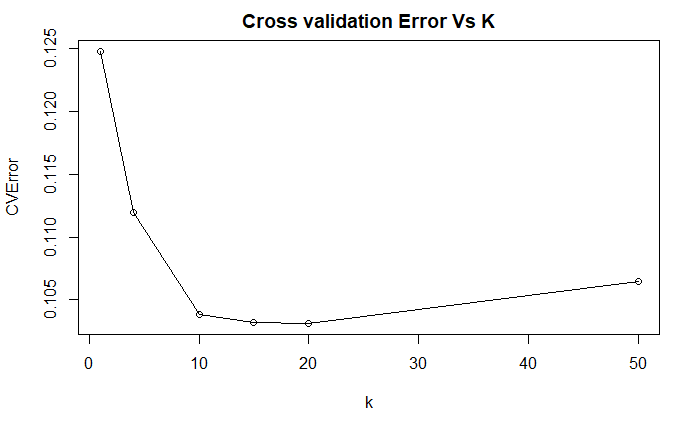

```r
ks = c(1,4,10,15,20,50)
errors = sapply(ks, crossValidationError, features = bank_train_n, target = bank_train$y)
plot(errors~ks, main ="Cross validation Error Vs K", xlab = "k", ylab="CVError")
lines(errors~ks)
```

14. Use the Knn function to train a knn model on the training set using the K value found above and get the predicted values for target variable y in the test set.

```r
bank_test_pred <-knn(bank_train_n, bank_test_n,bank_train_labels, k = 15)
summary(bank_test_pred)
```

```
  no  yes
8548  495
```

15. Compare the predicted target with the true target in the test set using a cross table.

```r
library(gmodels)

CrossTable(x = bank_test_labels, y = bank_test_pred, prop.chisq = FALSE)
```

```
   Cell Contents
|-------------------------|
|                       N |
|           N / Row Total |
|           N / Col Total |
|         N / Table Total |
|-------------------------|


Total Observations in Table:  9043


                 | bank_test_pred
bank_test_labels |        no |       yes | Row Total |
-----------------|-----------|-----------|-----------|
              no |      7813 |       188 |      8001 |
                 |     0.977 |     0.023 |     0.885 |
                 |     0.914 |     0.380 |           |
                 |     0.864 |     0.021 |           |
-----------------|-----------|-----------|-----------|
             yes |       735 |       307 |      1042 |
                 |     0.705 |     0.295 |     0.115 |
                 |     0.086 |     0.620 |           |
                 |     0.081 |     0.034 |           |
-----------------|-----------|-----------|-----------|
    Column Total |      8548 |       495 |      9043 |
                 |     0.945 |     0.055 |           |
-----------------|-----------|-----------|-----------|
```

Problem 2

1. Read the data and store in a data frame.set fileEncoding = “latin1” inside the read.csv method.

```r
corona <- read.csv("Corona_NLP_train.csv", fileEncoding = "latin1")
str(corona)
```

```
'data.frame':   41157 obs. of  6 variables:
 $ UserName     : int  3799 3800 3801 3802 3803 3804 3805 3806 3807 3808 ...
 $ ScreenName   : int  48751 48752 48753 48754 48755 48756 48757 48758 48759 48760 ...
 $ Location     : chr  "London" "UK" "Vagabonds" "" ...
 $ TweetAt      : chr  "16-03-2020" "16-03-2020" "16-03-2020" "16-03-2020" ...
 $ OriginalTweet: chr  "@MeNyrbie @Phil_Gahan @Chrisitv https://t.co/iFz9FAn2Pa and https://t.co/xX6ghGFzCC and https://t.co/I2NlzdxNo8" "advice Talk to your neighbours family to exchange phone numbers create contact list with phone numbers of neigh"| __truncated__ "Coronavirus Australia: Woolworths…
 $ Sentiment    : chr  "Neutral" "Positive" "Positive" "Positive" ...
```

```r
summary(corona)
```

```
    UserName       ScreenName      Location           TweetAt          OriginalTweet
 Min.   : 3799   Min.   :48751   Length:41157       Length:41157       Length:41157
 1st Qu.:14088   1st Qu.:59040   Class :character   Class :character   Class :character
 Median :24377   Median :69329   Mode  :character   Mode  :character   Mode  :character
 Mean   :24377   Mean   :69329
 3rd Qu.:34666   3rd Qu.:79618
 Max.   :44955   Max.   :89907
  Sentiment
 Length:41157
 Class :character
 Mode  :character
```

2. Randomize order of the rows

```r
set.seed(1)
shuffle_corona <- corona[sample(nrow(corona), replace = FALSE),]
str(shuffle_corona)
```

```
'data.frame':   41157 obs. of  6 variables:
 $ UserName     : int  28186 7848 15369 28971 36416 17701 12027 29103 28859 26104 ...
 $ ScreenName   : int  73138 52800 60321 73923 81368 62653 56979 74055 73811 71056 ...
 $ Location     : chr  "" "New York, USA" "Greensboro, NC" "? ? Big Hit Ent. ? ? " ...
 $ TweetAt      : chr  "26-03-2020" "18-03-2020" "20-03-2020" "30-03-2020" ...
 $ OriginalTweet: chr  "Order #ToiletPaper #covid19 #coronavirus #homeessentials #stayathome 1000 Sheets Per Roll, 36 Rolls Per Case by"| __truncated__ "Gro IntelligenceÂ\u0092s number-crunching points to slowly rebounding poultry prices as a key indicator of dama"| __truncated__ "My coworker just t…
 $ Sentiment    : chr  "Neutral" "Positive" "Negative" "Extremely Negative" ...
```

3. Convert sentiment into a factor variable with 3 levels :positive, neutral, and negative.

```r
shuffle_corona$Sentiment <- factor(shuffle_corona$Sentiment)
levels(shuffle_corona$Sentiment)[levels(shuffle_corona$Sentiment) == "Extremely Negative"] <- "Negative"
levels(shuffle_corona$Sentiment)[levels(shuffle_corona$Sentiment) == "Extremely Positive"] <- "Positive"
shuffle_corona$Sentiment
```

[output not shown]

[output cut: 87 more lines]

4. Create a text corpus from OriginalTweet variable, then clean the corpus.

```r
library(tm)
library(SnowballC)
corona_corpus <- VCorpus(VectorSource(shuffle_corona$OriginalTweet))
corona_corpus_clean <- tm_map(corona_corpus, content_transformer(tolower))
corona_corpus_clean <- tm_map(corona_corpus_clean, removeWords, stopwords())

replacePunctuation <- function(x) {
  gsub("[[:punct:]]+", " ", x)
}
corona_corpus_clean <- tm_map(corona_corpus_clean, replacePunctuation)
corona_corpus_clean <- tm_map(corona_corpus_clean, stemDocument)
corona_corpus_clean <- tm_map(corona_corpus_clean, stripWhitespace)
```

5. Create separate wordclouds for positive and negative tweets.

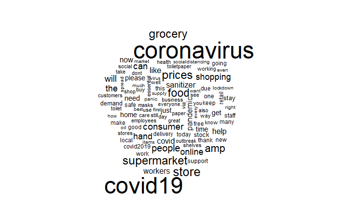

```r
library(wordcloud)
positive_wc <- subset(shuffle_corona, shuffle_corona$Sentiment == "Positive")
negative_wc <- subset(shuffle_corona, shuffle_corona$Sentiment == "Negative")
wordcloud(positive_wc$OriginalTweet, max.words = 100, scale = c(3, 0.5))
```

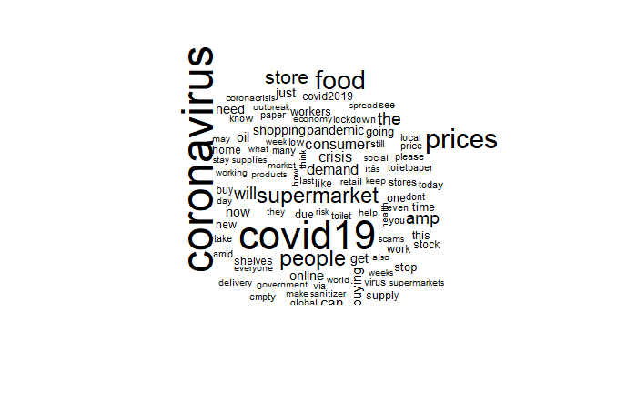

```r
wordcloud(negative_wc$OriginalTweet, max.words = 100, scale = c(3, 0.5))
```

There does not appear to be a visible difference between the frequent words for “positive” or “negative” tweets.

6. Create a document-term matrix from the cleaned corpus, then split the data into train and test sets. Use 80% for training and the rest for testing.

```r
corona_dtm <- DocumentTermMatrix(corona_corpus, control = list(
  tolower = TRUE,
  removeNumbers = TRUE,
  stopwords = TRUE,
  removePunctuation = TRUE,
  stemming = TRUE
))
```

```r
corona_dtm_train <- corona_dtm[1:32925,]
corona_dtm_test <- corona_dtm[32926:41157,]

corona_train_labels <- shuffle_corona[1:32925,]$Sentiment
corona_test_labels <- shuffle_corona[32926:41157,]$Sentiment
```

7. Remove words that appear less than 50 times in the training data. Convert frequencies in the DTM to binary yes/no features.

```r
corona_freq_words <- findFreqTerms(corona_dtm_train, 50)
corona_dtm_freq_train <- corona_dtm_train[, corona_freq_words]
corona_dtm_freq_test <- corona_dtm_test[, corona_freq_words]

convert_counts <- function(x) {
  x <- ifelse(x > 0, "Yes", "No")
}
corona_train <- apply(corona_dtm_freq_train, MARGIN = 2, convert_counts)
corona_test <- apply(corona_dtm_freq_test, MARGIN = 2, convert_counts )
```

8. Train a Naive Bayes classifier on the training data and evaluate its performance on the test data. use a cross table between the model’s prediction on the test data and the true test labels.

```r
library(e1071)
corona_classifier <- naiveBayes(corona_train, corona_train_labels)
corona_test_pred <- predict(corona_classifier, corona_test)
library(gmodels)
CrossTable(corona_test_pred, corona_test_labels, prop.chisq = FALSE, prop.t = FALSE, dnn = c('predicted','actual'))
```

```
   Cell Contents
|-------------------------|
|                       N |
|           N / Row Total |
|           N / Col Total |
|-------------------------|


Total Observations in Table:  8232


             | actual
   predicted |  Negative |  Positive |   Neutral | Row Total |
-------------|-----------|-----------|-----------|-----------|
    Negative |      2044 |       607 |       214 |      2865 |
             |     0.713 |     0.212 |     0.075 |     0.348 |
             |     0.663 |     0.169 |     0.138 |           |
-------------|-----------|-----------|-----------|-----------|
    Positive |       627 |      2576 |       279 |      3482 |
             |     0.180 |     0.740 |     0.080 |     0.423 |
             |     0.204 |     0.717 |     0.179 |           |
-------------|-----------|-----------|-----------|-----------|
     Neutral |       410 |       412 |      1063 |      1885 |
             |     0.218 |     0.219 |     0.564 |     0.229 |
             |     0.133 |     0.115 |     0.683 |           |
-------------|-----------|-----------|-----------|-----------|
Column Total |      3081 |      3595 |      1556 |      8232 |
             |     0.374 |     0.437 |     0.189 |           |
-------------|-----------|-----------|-----------|-----------|
```

Overall accuracy would be 5683/ 8232 = 69%.

Precision = TP/(TP+FP) recall= TP/(TP+FN)